# INN Hotels Project

## Context

A significant number of hotel bookings are called-off due to cancellations or no-shows. The typical reasons for cancellations include change of plans, scheduling conflicts, etc. This is often made easier by the option to do so free of charge or preferably at a low cost which is beneficial to hotel guests but it is a less desirable and possibly revenue-diminishing factor for hotels to deal with. Such losses are particularly high on last-minute cancellations.

The new technologies involving online booking channels have dramatically changed customers’ booking possibilities and behavior. This adds a further dimension to the challenge of how hotels handle cancellations, which are no longer limited to traditional booking and guest characteristics.

The cancellation of bookings impact a hotel on various fronts:

- Loss of resources (revenue) when the hotel cannot resell the room.
- Additional costs of distribution channels by increasing commissions or paying for publicity to help sell these rooms.
- Lowering prices last minute, so the hotel can resell a room, resulting in reducing the profit margin.
- Human resources to make arrangements for the guests.

## Objective

The increasing number of cancellations calls for a Machine Learning based solution that can help in predicting which booking is likely to be canceled. INN Hotels Group has a chain of hotels in Portugal, they are facing problems with the high number of booking cancellations and have reached out to your firm for data-driven solutions. You as a data scientist have to analyze the data provided to find which factors have a high influence on booking cancellations, build a predictive model that can predict which booking is going to be canceled in advance, and help in formulating profitable policies for cancellations and refunds.

## Data Description

The data contains the different attributes of customers' booking details. The detailed data dictionary is given below.

**Data Dictionary**

- Booking_ID: unique identifier of each booking
- no_of_adults: Number of adults
- no_of_children: Number of Children
- no_of_weekend_nights: Number of weekend nights (Saturday or Sunday) the guest stayed or booked to stay at the hotel
- no_of_week_nights: Number of week nights (Monday to Friday) the guest stayed or booked to stay at the hotel
- type_of_meal_plan: Type of meal plan booked by the customer:
  - Not Selected – No meal plan selected
  - Meal Plan 1 – Breakfast
  - Meal Plan 2 – Half board (breakfast and one other meal)
  - Meal Plan 3 – Full board (breakfast, lunch, and dinner)
- required_car_parking_space: Does the customer require a car parking space? (0 - No, 1- Yes)
- room_type_reserved: Type of room reserved by the customer. The values are ciphered (encoded) by INN Hotels.
- lead_time: Number of days between the date of booking and the arrival date
- arrival_year: Year of arrival date
- arrival_month: Month of arrival date
- arrival_date: Date of the month
- market_segment_type: Market segment designation.
- repeated_guest: Is the customer a repeated guest? (0 - No, 1- Yes)
- no_of_previous_cancellations: Number of previous bookings that were canceled by the customer prior to the current booking
- no_of_previous_bookings_not_canceled: Number of previous bookings not canceled by the customer prior to the current booking
- avg_price_per_room: Average price per day of the reservation; prices of the rooms are dynamic. (in euros)
- no_of_special_requests: Total number of special requests made by the customer (e.g. high floor, view from the room, etc)
- booking_status: Flag indicating if the booking was canceled or not.

## Importing necessary libraries and data

```python
# this will help in making the Python code more structured automatically (help adhere to good coding practices)
# %load_ext nb_black

import warnings

warnings.filterwarnings("ignore")
from statsmodels.tools.sm_exceptions import ConvergenceWarning

warnings.simplefilter("ignore", ConvergenceWarning)

# Libraries to help with reading and manipulating data
import pandas as pd
import numpy as np

# libaries to help with data visualization
import matplotlib.pyplot as plt
import seaborn as sns

# Removes the limit for the number of displayed columns
pd.set_option("display.max_columns", None)
# Sets the limit for the number of displayed rows
pd.set_option("display.max_rows", 200)
# setting the precision of floating numbers to 5 decimal points
pd.set_option("display.float_format", lambda x: "%.5f" % x)

# Library to split data
from sklearn.model_selection import train_test_split

# To build model for prediction
import statsmodels.stats.api as sms
from statsmodels.stats.outliers_influence import variance_inflation_factor
import statsmodels.api as sm
from statsmodels.tools.tools import add_constant
from sklearn.tree import DecisionTreeClassifier
from sklearn import tree

# To tune different models
from sklearn.model_selection import GridSearchCV


# To get diferent metric scores
from sklearn.metrics import (
    f1_score,
    accuracy_score,
    recall_score,
    precision_score,
    confusion_matrix,
    roc_auc_score,
    plot_confusion_matrix,
    precision_recall_curve,
    roc_curve,
    make_scorer,
)
```

## Data Overview

- Observations
- Sanity checks

### IMPORT DATASET

```python
hotel=pd.read_csv('C:/Users/AK153/GREAT LEARNING/MODULE 4 Supervised Learning Classification INN HOTELS/INNHotelsGroup.csv')
```

```python
# copying data to another variable to avoid any changes to original data
data=hotel.copy()
```

#### View The First and Last Five Rows of the dataset

```python
data.head()# Writing the code to view top 5 rows of the data
```

|  | Booking_ID | no_of_adults | no_of_children | no_of_weekend_nights | no_of_week_nights | type_of_meal_plan | required_car_parking_space | room_type_reserved | lead_time | arrival_year | arrival_month | arrival_date | market_segment_type | repeated_guest | no_of_previous_cancellations | no_of_previous_bookings_not_canceled | avg_price_per_room | no_of_special_requests | booking_status |
| --- | --- | --- | --- | --- | --- | --- | --- | --- | --- | --- | --- | --- | --- | --- | --- | --- | --- | --- | --- |
| 0 | INN00001 | 2 | 0 | 1 | 2 | Meal Plan 1 | 0 | Room_Type 1 | 224 | 2017 | 10 | 2 | Offline | 0 | 0 | 0 | 65.00000 | 0 | Not_Canceled |
| 1 | INN00002 | 2 | 0 | 2 | 3 | Not Selected | 0 | Room_Type 1 | 5 | 2018 | 11 | 6 | Online | 0 | 0 | 0 | 106.68000 | 1 | Not_Canceled |
| 2 | INN00003 | 1 | 0 | 2 | 1 | Meal Plan 1 | 0 | Room_Type 1 | 1 | 2018 | 2 | 28 | Online | 0 | 0 | 0 | 60.00000 | 0 | Canceled |
| 3 | INN00004 | 2 | 0 | 0 | 2 | Meal Plan 1 | 0 | Room_Type 1 | 211 | 2018 | 5 | 20 | Online | 0 | 0 | 0 | 100.00000 | 0 | Canceled |
| 4 | INN00005 | 2 | 0 | 1 | 1 | Not Selected | 0 | Room_Type 1 | 48 | 2018 | 4 | 11 | Online | 0 | 0 | 0 | 94.50000 | 0 | Canceled |

```python
data.tail()# Writing the code to view top 5 rows of the data
```

|  | Booking_ID | no_of_adults | no_of_children | no_of_weekend_nights | no_of_week_nights | type_of_meal_plan | required_car_parking_space | room_type_reserved | lead_time | arrival_year | arrival_month | arrival_date | market_segment_type | repeated_guest | no_of_previous_cancellations | no_of_previous_bookings_not_canceled | avg_price_per_room | no_of_special_requests | booking_status |
| --- | --- | --- | --- | --- | --- | --- | --- | --- | --- | --- | --- | --- | --- | --- | --- | --- | --- | --- | --- |
| 36270 | INN36271 | 3 | 0 | 2 | 6 | Meal Plan 1 | 0 | Room_Type 4 | 85 | 2018 | 8 | 3 | Online | 0 | 0 | 0 | 167.80000 | 1 | Not_Canceled |
| 36271 | INN36272 | 2 | 0 | 1 | 3 | Meal Plan 1 | 0 | Room_Type 1 | 228 | 2018 | 10 | 17 | Online | 0 | 0 | 0 | 90.95000 | 2 | Canceled |
| 36272 | INN36273 | 2 | 0 | 2 | 6 | Meal Plan 1 | 0 | Room_Type 1 | 148 | 2018 | 7 | 1 | Online | 0 | 0 | 0 | 98.39000 | 2 | Not_Canceled |
| 36273 | INN36274 | 2 | 0 | 0 | 3 | Not Selected | 0 | Room_Type 1 | 63 | 2018 | 4 | 21 | Online | 0 | 0 | 0 | 94.50000 | 0 | Canceled |
| 36274 | INN36275 | 2 | 0 | 1 | 2 | Meal Plan 1 | 0 | Room_Type 1 | 207 | 2018 | 12 | 30 | Offline | 0 | 0 | 0 | 161.67000 | 0 | Not_Canceled |

### Understand the Shape of The Dataset

```python
data.shape # Writing the code to view dimensions of the data
```

```
(36275, 19)
```

#### Observation:

The datset consists of 36275 rows and 19 columns.

### Check the Datatypes of the Coumns for the Dataset.

```python
data.info()
```

```
<class 'pandas.core.frame.DataFrame'>
RangeIndex: 36275 entries, 0 to 36274
Data columns (total 19 columns):
 #   Column                                Non-Null Count  Dtype
---  ------                                --------------  -----
 0   Booking_ID                            36275 non-null  object
 1   no_of_adults                          36275 non-null  int64
 2   no_of_children                        36275 non-null  int64
 3   no_of_weekend_nights                  36275 non-null  int64
 4   no_of_week_nights                     36275 non-null  int64
 5   type_of_meal_plan                     36275 non-null  object
 6   required_car_parking_space            36275 non-null  int64
 7   room_type_reserved                    36275 non-null  object
 8   lead_time                             36275 non-null  int64
 9   arrival_year                          36275 non-null  int64
 10  arrival_month                         36275 non-null  int64
 11  arrival_date                          36275 non-null  int64
 12  market_segment_type                   36275 non-null  object
 13  repeated_guest                        36275 non-null  int64
 14  no_of_previous_cancellations          36275 non-null  int64
 15  no_of_previous_bookings_not_canceled  36275 non-null  int64
 16  avg_price_per_room                    36275 non-null  float64
 17  no_of_special_requests                36275 non-null  int64
 18  booking_status                        36275 non-null  object
dtypes: float64(1), int64(13), object(5)
memory usage: 5.3+ MB
```

```python
# checking for duplicate values
data.duplicated().value_counts()
```

```
False    36275
dtype: int64
```

#### Observations:

- The dataset contains 13 integer data types, 5 object data types, and 1 float data type, resulting in a total of 14 numerical and 5 categorical data types.
- The count of non-null values remains the same as the total number of rows, indicating no missing values.
- The data does not consist of any duplicate values.

```python
# Returns Statistical summary of the data for Numerical Datatype
data.describe(exclude=[object]).T
```

|  | count | mean | std | min | 25% | 50% | 75% | max |
| --- | --- | --- | --- | --- | --- | --- | --- | --- |
| no_of_adults | 36275.00000 | 1.84496 | 0.51871 | 0.00000 | 2.00000 | 2.00000 | 2.00000 | 4.00000 |
| no_of_children | 36275.00000 | 0.10528 | 0.40265 | 0.00000 | 0.00000 | 0.00000 | 0.00000 | 10.00000 |
| no_of_weekend_nights | 36275.00000 | 0.81072 | 0.87064 | 0.00000 | 0.00000 | 1.00000 | 2.00000 | 7.00000 |
| no_of_week_nights | 36275.00000 | 2.20430 | 1.41090 | 0.00000 | 1.00000 | 2.00000 | 3.00000 | 17.00000 |
| required_car_parking_space | 36275.00000 | 0.03099 | 0.17328 | 0.00000 | 0.00000 | 0.00000 | 0.00000 | 1.00000 |
| lead_time | 36275.00000 | 85.23256 | 85.93082 | 0.00000 | 17.00000 | 57.00000 | 126.00000 | 443.00000 |
| arrival_year | 36275.00000 | 2017.82043 | 0.38384 | 2017.00000 | 2018.00000 | 2018.00000 | 2018.00000 | 2018.00000 |
| arrival_month | 36275.00000 | 7.42365 | 3.06989 | 1.00000 | 5.00000 | 8.00000 | 10.00000 | 12.00000 |
| arrival_date | 36275.00000 | 15.59700 | 8.74045 | 1.00000 | 8.00000 | 16.00000 | 23.00000 | 31.00000 |
| repeated_guest | 36275.00000 | 0.02564 | 0.15805 | 0.00000 | 0.00000 | 0.00000 | 0.00000 | 1.00000 |
| no_of_previous_cancellations | 36275.00000 | 0.02335 | 0.36833 | 0.00000 | 0.00000 | 0.00000 | 0.00000 | 13.00000 |
| no_of_previous_bookings_not_canceled | 36275.00000 | 0.15341 | 1.75417 | 0.00000 | 0.00000 | 0.00000 | 0.00000 | 58.00000 |
| avg_price_per_room | 36275.00000 | 103.42354 | 35.08942 | 0.00000 | 80.30000 | 99.45000 | 120.00000 | 540.00000 |
| no_of_special_requests | 36275.00000 | 0.61966 | 0.78624 | 0.00000 | 0.00000 | 0.00000 | 1.00000 | 5.00000 |

#### Observations:

```python
# Returns Statistical summary of the data for object Datatype
data.describe(exclude=[np.number]).T
```

|  | count | unique | top | freq |
| --- | --- | --- | --- | --- |
| Booking_ID | 36275 | 36275 | INN13594 | 1 |
| type_of_meal_plan | 36275 | 4 | Meal Plan 1 | 27835 |
| room_type_reserved | 36275 | 7 | Room_Type 1 | 28130 |
| market_segment_type | 36275 | 5 | Online | 23214 |
| booking_status | 36275 | 2 | Not_Canceled | 24390 |

#### Observations :

- Guests prefer Mean Plan 1 for meals, Room Type 1 for accommodations, and online booking for reservations.
- Most bookings are not cancelled, indicating a relatively stable booking status.

#### Let's drop the Booking_ID column first before we proceed forward.

```python
# Writing the code to drop the Booking_ID column from the dataframe
data=data.drop(['Booking_ID'],axis=1)
```

```python
data.head()
```

|  | no_of_adults | no_of_children | no_of_weekend_nights | no_of_week_nights | type_of_meal_plan | required_car_parking_space | room_type_reserved | lead_time | arrival_year | arrival_month | arrival_date | market_segment_type | repeated_guest | no_of_previous_cancellations | no_of_previous_bookings_not_canceled | avg_price_per_room | no_of_special_requests | booking_status |
| --- | --- | --- | --- | --- | --- | --- | --- | --- | --- | --- | --- | --- | --- | --- | --- | --- | --- | --- |
| 0 | 2 | 0 | 1 | 2 | Meal Plan 1 | 0 | Room_Type 1 | 224 | 2017 | 10 | 2 | Offline | 0 | 0 | 0 | 65.00000 | 0 | Not_Canceled |
| 1 | 2 | 0 | 2 | 3 | Not Selected | 0 | Room_Type 1 | 5 | 2018 | 11 | 6 | Online | 0 | 0 | 0 | 106.68000 | 1 | Not_Canceled |
| 2 | 1 | 0 | 2 | 1 | Meal Plan 1 | 0 | Room_Type 1 | 1 | 2018 | 2 | 28 | Online | 0 | 0 | 0 | 60.00000 | 0 | Canceled |
| 3 | 2 | 0 | 0 | 2 | Meal Plan 1 | 0 | Room_Type 1 | 211 | 2018 | 5 | 20 | Online | 0 | 0 | 0 | 100.00000 | 0 | Canceled |
| 4 | 2 | 0 | 1 | 1 | Not Selected | 0 | Room_Type 1 | 48 | 2018 | 4 | 11 | Online | 0 | 0 | 0 | 94.50000 | 0 | Canceled |

## Exploratory Data Analysis (EDA)

- EDA is an important part of any project involving data.
- It is important to investigate and understand the data better before building a model with it.
- A few questions have been mentioned below which will help you approach the analysis in the right manner and generate insights from the data.
- A thorough analysis of the data, in addition to the questions mentioned below, should be done.

**Leading Questions**:

1. What are the busiest months in the hotel?
2. Which market segment do most of the guests come from?
3. Hotel rates are dynamic and change according to demand and customer demographics. What are the differences in room prices in different market segments?
4. What percentage of bookings are canceled?
5. Repeating guests are the guests who stay in the hotel often and are important to brand equity. What percentage of repeating guests cancel?
6. Many guests have special requirements when booking a hotel room. Do these requirements affect booking cancellation?

## Univariate Analysis

```python
def histogram_boxplot(data, feature,xlabel,ylabel,figsize=(15, 10), kde=True, bins=None,hist_edgecolor='black'):
    """
    Boxplot and histogram combined

    data: dataframe
    feature: dataframe column
    figsize: size of figure (default (15,10))
    kde: whether to show the density curve (default False)
    bins: number of bins for histogram (default None)
    """
    f2, (ax_box2, ax_hist2) = plt.subplots(
        nrows=2,  # Number of rows of the subplot grid= 2
        sharex=True,  # x-axis will be shared among all subplots
        gridspec_kw={"height_ratios": (0.25, 0.75)},
        figsize=figsize,
    )  # creating the 2 subplots
    sns.boxplot(
        data=data, x=feature, ax=ax_box2, showmeans=True, color="purple",meanprops={"marker":"o", "markerfacecolor":"red", "markeredgecolor":"black"},boxprops=dict(linewidth=1, edgecolor='black'),medianprops={"color": "black"},whiskerprops={'color': 'black', 'linewidth': 1},capprops={'color': 'black', 'linewidth': 1}
    )  # boxplot will be created and a triangle will indicate the mean value of the column
    ax_box2.set_xlabel(xlabel)
    sns.histplot(
        data=data, x=feature, kde=kde, ax=ax_hist2, bins=bins,color='orange',edgecolor=hist_edgecolor
    ) if bins else sns.histplot(
        data=data, x=feature, kde=kde, ax=ax_hist2,color='orange',edgecolor=hist_edgecolor
    )  # For histogram
    ax_hist2.axvline(
        data[feature].mean(), color="red", linestyle="--"
    )  # Add mean to the histogram
    ax_hist2.axvline(
        data[feature].median(), color="black", linestyle="-"
    )  # Add median to the histogram
    ax_hist2.set_xlabel(xlabel)
    ax_hist2.set_ylabel(ylabel)
```

```python
def labeled_barplot(data, feature,xlabel,ylabel, perc=True, n=None):
    """
    Barplot with percentage at the top

    data: dataframe
    feature: dataframe column
    perc: whether to display percentages instead of count (default is False)
    n: displays the top n category levels (default is None, i.e., display all levels)
    """

    total = len(data[feature])  # length of the column
    count = data[feature].nunique()

    if n is None:
        if count <= 3:
            plt.figure(figsize=(count + 4, count + 4))
        elif count>3 and count <= 15:
            plt.figure(figsize=(count + 2, count + 3 ))
        else:
            plt.figure(figsize=(count + 20, count + 2))
    else:
        if n <= 15:
            plt.figure(figsize=(n + 2, count))
        else:
            plt.figure(figsize=(n + 20, count))



    if count<=3:
        plt.xticks(rotation=45, fontsize=count*6)# Adjust the fonts of x-axis ticks
        plt.yticks(fontsize=count*4)
    elif count>3 and count<=5:
        plt.xticks(rotation=45, fontsize=count*4)# Adjust the fonts of x-axis ticks
        plt.yticks(fontsize=count*2.5)  # Adjust the fontsize for y-axis ticks as needed
    elif count>5 and count<=12:
        plt.xticks(rotation=45, fontsize=count*2)# Adjust the fonts of x-axis ticks
        plt.yticks(fontsize=count*2.5)  # Adjust the fontsize for y-axis ticks as needed
    else:
        plt.xticks(rotation=45, fontsize=count*1)# Adjust the fonts of x-axis ticks
        plt.yticks(fontsize=count*1.3)  # Adjust the fontsize for y-axis ticks as needed
    ax = sns.countplot(
        data=data,
        x=feature,
        palette="Set1",
        order=data[feature].value_counts().index[:n],
    )
    ax.set_xlabel(xlabel)
    if count<=3:
        plt.xlabel(xlabel,rotation=0, fontsize=count*6)# Adjust the fonts of x-axis label
    elif count>3 and count<=5:
        plt.xlabel(xlabel,rotation=0, fontsize=count*4)# Adjust the fonts of x-axis label
    elif count>5 and count<=12:
        plt.xlabel(xlabel,rotation=0, fontsize=count*2)# Adjust the fonts of x-axis label
    else:
        plt.xlabel(xlabel,rotation=0, fontsize=count*1.2)# Adjust the fonts of x-axis label
    ax.set_ylabel(ylabel)
    if count<=3:
        plt.ylabel(ylabel,rotation=90, fontsize=count*6)# Adjust the fonts of y-axis label
    elif count>3 and count<=5:
        plt.ylabel(ylabel,rotation=90, fontsize=count*4)# Adjust the fonts of y-axis label
    elif count>5 and count<=12:
        plt.ylabel(ylabel,rotation=90, fontsize=count*2)# Adjust the fonts of y-axis label
    else:
        plt.ylabel(ylabel,rotation=90, fontsize=count*1.2)# Adjust the fonts of y-axis label

    for patch in ax.patches:
        if perc == True:
            label = "{:.1f}%".format(
                100 * patch.get_height() / total
            )  # percentage of each class of the category
        else:
            label = patch.get_height()  # count of each level of the category

        x = patch.get_x() + patch.get_width() / 2  # width of the plot
        y = patch.get_height()  # height of the plot

        if count<= 15:  # Condition for less than or equal to 15 bars
            ax.annotate(
                label,
                (x, y),
                ha="center",
                va="center",
                size=16,
                xytext=(0, 9),
                textcoords="offset points",
            )  # annotate the percentage
        elif count > 15 and count <= 25:  # Condition for 15 to 25 bars
            ax.annotate(
                label,
                (x, y),
                ha="center",
                va="center",
                size=20,
                xytext=(0, 9),
                textcoords="offset points",
            )  # annotate the percentage
        else:  # Condition for more than 25 bars
            ax.annotate(
                label,
                (x, y),
                ha="center",
                va="center",
                size=35,
                xytext=(0, 9),
                textcoords="offset points",
            )  # annotate the percentage

    plt.show()  # show the plot
```

```python
# Function to create Stacked Barplot
def stacked_barplot(data, predictor, target, Xlabel, ax=None):
    """
    Print the category counts and plot a stacked bar chart

    data: dataframe
    predictor: independent variable
    target: target variable
    ax: AxesSubplot, optional
        The AxesSubplot to plot on. If not provided, a new subplot will be created.
    """
    count = data[predictor].nunique()
    sorter = data[target].value_counts().index[-1]
    tab1 = pd.crosstab(data[predictor], data[target], margins=True).sort_values(
        by=sorter, ascending=False
    )
    tab = pd.crosstab(data[predictor], data[target], normalize="index").sort_values(
        by=sorter, ascending=False
    )
    if ax is None:
        ax = plt.gca()  # Get the current AxesSubplot if ax is not provided
    tab.plot(kind="bar", stacked=True, ax=ax,edgecolor="black",color=['mediumseagreen','salmon'])
    ax.set_xlabel(Xlabel, fontsize=10)
    ax.set_xticklabels(ax.get_xticklabels(), rotation=45)
    ax.legend_ = None
    return ax
```

```python
# Function to print the top 5 frequent values and their percentage,largest 5 values and their count, Maximum and Minimum value,Mean and Median of the column
def univariate_analysis(col, label):
    # Display the top 5 values and their percentages
    print(f"1.  The top 5 frequent {label} and their percentage")
    print(data[col].value_counts(normalize=True).nlargest(5) * 100)
    print()
    # Display the top 5 values
    print(f"2.  The Top 5 largest {label} values and their count")
    print(data[col].value_counts(normalize=True).sort_index(ascending=False).head(5)*100)
    print()
    # Display the maximum and minimum values
    print(f"3.  The Maximum of {label} is {data[col].max()}  and the Minimum of {label} is {data[col].min()} ")
    print()
    # Display the mean and median values
    print(f"4.  The Mean of {label} is {round(data[col].mean(), 2)}  and the Median of {label} is {data[col].median()} ")
```

```python
### function to plot distributions wrt target


def distribution_plot_wrt_target(data, predictor, target ,xlabel1,xlabel2):

    fig, axs = plt.subplots(2, 2, figsize=(12, 10))

    target_uniq = data[target].unique()

    axs[0, 0].set_title("Distribution of target for target=" + str(target_uniq[0]))
    sns.histplot(
        data=data[data[target] == target_uniq[0]],
        x=predictor,
        kde=True,
        ax=axs[0, 0],
        color="orange",
        stat="density",
    )

    axs[0, 1].set_title("Distribution of target for target=" + str(target_uniq[1]))
    sns.histplot(
        data=data[data[target] == target_uniq[1]],
        x=predictor,
        kde=True,
        ax=axs[0, 1],
        color="red",
        stat="density",
    )

    axs[1, 0].set_title("Boxplot w.r.t target")
    sns.boxplot(data=data, x=target, y=predictor, ax=axs[1, 0], palette="mako")

    axs[1, 1].set_title("Boxplot (without outliers) w.r.t target")
    sns.boxplot(
        data=data,
        x=target,
        y=predictor,
        ax=axs[1, 1],
        showfliers=False,
        palette="mako",
        showmeans=True
    )

    plt.tight_layout()
    plt.show()
```

### Observations On Leadtime

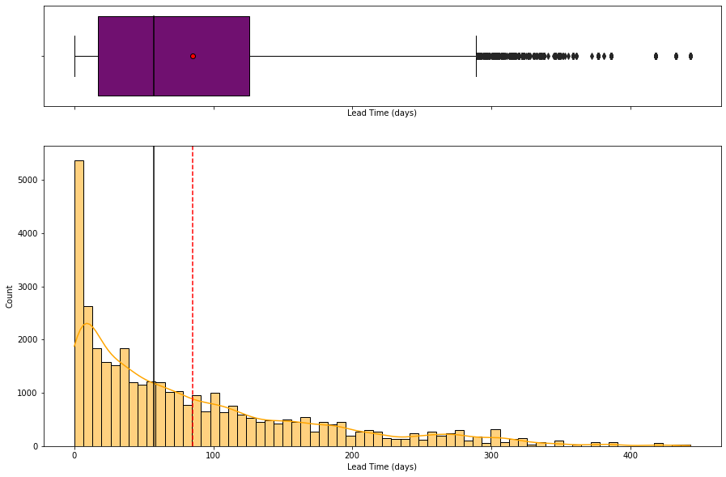

```python
histogram_boxplot(data,'lead_time',xlabel='Lead Time (days)', ylabel='Count')
```

##### Observations:

- Distribution of lead time is right-skewed, indicating that most bookings are made closer to the arrival date.
- There are also a significant number of outliers where customers have made bookings around 300-500 days in advance, indicating long-term planning or advance bookings for special events or occasions.
- Some customers have made bookings on the same day of arrival, indicating last-minute bookings or spontaneous travel plans.
- Range of Lead Time is from 0 to 500 days indicating there is a wide range of lead times for bookings, with some guests planning well in advance and others making last-minute bookings.

### Observations On Average Price Per Room

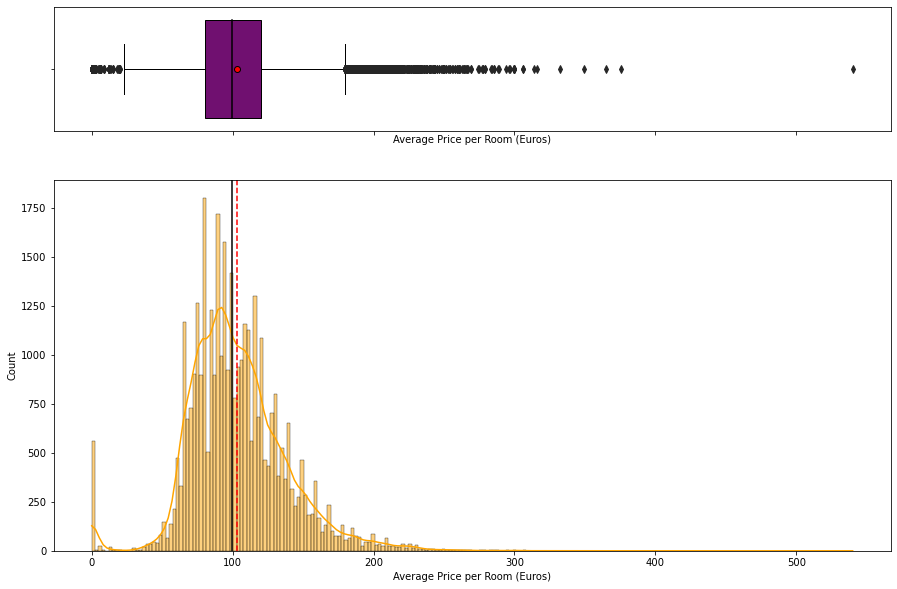

```python
histogram_boxplot(data,'avg_price_per_room',xlabel='Average Price per Room (Euros)', ylabel='Count')# Writing the code to create histogram_boxplot for average price per room
```

```python
data[data["avg_price_per_room"]==0]
```

|  | no_of_adults | no_of_children | no_of_weekend_nights | no_of_week_nights | type_of_meal_plan | required_car_parking_space | room_type_reserved | lead_time | arrival_year | arrival_month | arrival_date | market_segment_type | repeated_guest | no_of_previous_cancellations | no_of_previous_bookings_not_canceled | avg_price_per_room | no_of_special_requests | booking_status |
| --- | --- | --- | --- | --- | --- | --- | --- | --- | --- | --- | --- | --- | --- | --- | --- | --- | --- | --- |
| 63 | 1 | 0 | 0 | 1 | Meal Plan 1 | 0 | Room_Type 1 | 2 | 2017 | 9 | 10 | Complementary | 0 | 0 | 0 | 0.00000 | 1 | Not_Canceled |
| 145 | 1 | 0 | 0 | 2 | Meal Plan 1 | 0 | Room_Type 1 | 13 | 2018 | 6 | 1 | Complementary | 1 | 3 | 5 | 0.00000 | 1 | Not_Canceled |
| 209 | 1 | 0 | 0 | 0 | Meal Plan 1 | 0 | Room_Type 1 | 4 | 2018 | 2 | 27 | Complementary | 0 | 0 | 0 | 0.00000 | 1 | Not_Canceled |
| 266 | 1 | 0 | 0 | 2 | Meal Plan 1 | 0 | Room_Type 1 | 1 | 2017 | 8 | 12 | Complementary | 1 | 0 | 1 | 0.00000 | 1 | Not_Canceled |
| 267 | 1 | 0 | 2 | 1 | Meal Plan 1 | 0 | Room_Type 1 | 4 | 2017 | 8 | 23 | Complementary | 0 | 0 | 0 | 0.00000 | 1 | Not_Canceled |
| ... | ... | ... | ... | ... | ... | ... | ... | ... | ... | ... | ... | ... | ... | ... | ... | ... | ... | ... |
| 35983 | 1 | 0 | 0 | 1 | Meal Plan 1 | 0 | Room_Type 7 | 0 | 2018 | 6 | 7 | Complementary | 1 | 4 | 17 | 0.00000 | 1 | Not_Canceled |
| 36080 | 1 | 0 | 1 | 1 | Meal Plan 1 | 0 | Room_Type 7 | 0 | 2018 | 3 | 21 | Complementary | 1 | 3 | 15 | 0.00000 | 1 | Not_Canceled |
| 36114 | 1 | 0 | 0 | 1 | Meal Plan 1 | 0 | Room_Type 1 | 1 | 2018 | 3 | 2 | Online | 0 | 0 | 0 | 0.00000 | 0 | Not_Canceled |
| 36217 | 2 | 0 | 2 | 1 | Meal Plan 1 | 0 | Room_Type 2 | 3 | 2017 | 8 | 9 | Online | 0 | 0 | 0 | 0.00000 | 2 | Not_Canceled |
| 36250 | 1 | 0 | 0 | 2 | Meal Plan 2 | 0 | Room_Type 1 | 6 | 2017 | 12 | 10 | Online | 0 | 0 | 0 | 0.00000 | 0 | Not_Canceled |

545 rows × 18 columns

##### Observations:

- Distribution of the average price per room is skewed to the right, with outliers present on both the higher and lower ends of the price range.
- The majority of rooms have an average price around 100 EUR.
- However, there is one observation where the average price per room is more than 500 euros, which is significantly higher than the rest of the values. Instead of dropping this observation, it is suggested to clip it to the upper whisker to retain the information.
- Furthermore, there are some rooms with an average price per room equal to 0 and require further analysis.

```python
data.loc[data['avg_price_per_room']==0,"market_segment_type"].value_counts()
```

```
Complementary    354
Online           191
Name: market_segment_type, dtype: int64
```

```python
# Calculating the 25th quantile
Q1=data['avg_price_per_room'].quantile(0.25)

# Calculating the 75th quantile
Q3=data['avg_price_per_room'].quantile(0.75)

# Calculating the IQR
IQR=Q3-Q1

# Calculating the value of upper whisker
Upper_whisker=Q3 + 1.5*IQR
Upper_whisker
```

```
179.55
```

```python
#assinging the outliers value of upper whisker
data.loc[data["avg_price_per_room"]>=500,"avg_price_per_room"]=Upper_whisker
```

### Number of Previous Bookings that were Cancelled

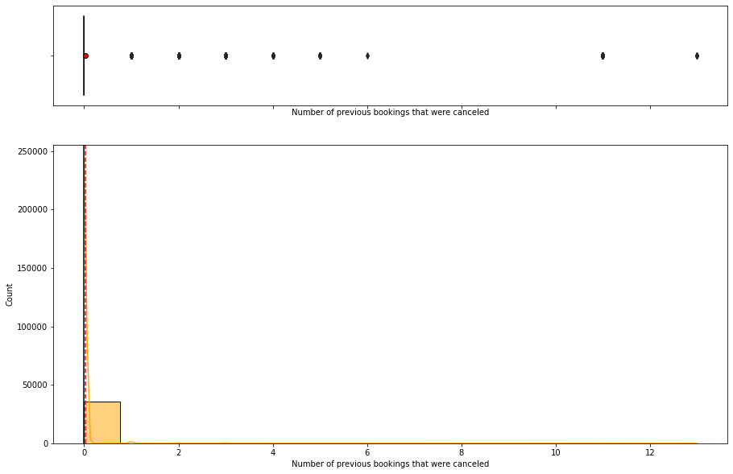

```python
# Writing the code to create histogram_boxplot for number of previous booking that were canceled
histogram_boxplot(data=data,feature="no_of_previous_cancellations",xlabel='Number of previous bookings that were canceled', ylabel='Count')
```

```python
# Call the univariate_analysis function
univariate_analysis('no_of_previous_cancellations', 'Number of previous bookings that were canceled')
```

```
1.  The top 5 frequent Number of previous bookings that were canceled and their percentage
0    99.06823
1     0.54583
2     0.12681
3     0.11854
11    0.06892
Name: no_of_previous_cancellations, dtype: float64

2.  The Top 5 largest Number of previous bookings that were canceled values and their count
13   0.01103
11   0.06892
6    0.00276
5    0.03032
4    0.02757
Name: no_of_previous_cancellations, dtype: float64

3.  The Maximum of Number of previous bookings that were canceled is 13  and the Minimum of Number of previous bookings that were canceled is 0

4.  The Mean of Number of previous bookings that were canceled is 0.02  and the Median of Number of previous bookings that were canceled is 0.0
```

### Observations on Number of Previous Bookings not Cancelled

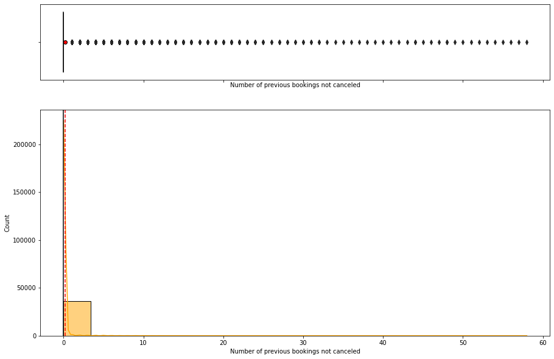

```python
# Writing the code to create histogram_boxplot for number of previous booking not canceled
histogram_boxplot(data=data,feature="no_of_previous_bookings_not_canceled",xlabel='Number of previous bookings not canceled', ylabel='Count')
```

```python
# Call the univariate_analysis function
univariate_analysis('no_of_previous_bookings_not_canceled', 'Number of previous bookings not canceled')
```

```
1.  The top 5 frequent Number of previous bookings not canceled and their percentage
0   97.76154
1    0.62853
2    0.30875
3    0.22054
4    0.17919
Name: no_of_previous_bookings_not_canceled, dtype: float64

2.  The Top 5 largest Number of previous bookings not canceled values and their count
58   0.00276
57   0.00276
56   0.00276
55   0.00276
54   0.00276
Name: no_of_previous_bookings_not_canceled, dtype: float64

3.  The Maximum of Number of previous bookings not canceled is 58  and the Minimum of Number of previous bookings not canceled is 0

4.  The Mean of Number of previous bookings not canceled is 0.15  and the Median of Number of previous bookings not canceled is 0.0
```

### Observations On Number Of Adults

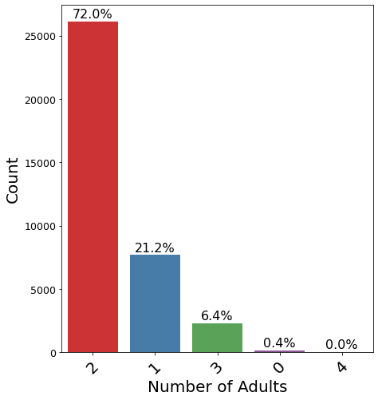

```python
labeled_barplot(data=data, feature='no_of_adults', xlabel='Number of Adults', ylabel='Count',perc=True)
```

##### Observations:

Approximately 72% of the bookings are made for two adults

### Observation On Number Of Children

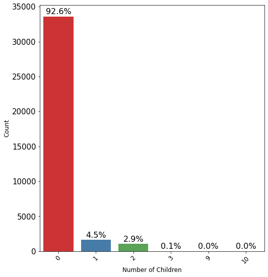

```python
labeled_barplot(data=data, feature='no_of_children', xlabel='Number of Children', ylabel='Count',perc=True)
```

#### Observations:

Roughly 92% of the bookings did not include children. However, there are a few bookings with child counts of 9 and 10, which require further analysis of the data.

#### Children Count> 3

```python
data[(data['no_of_children']==9) | (data['no_of_children']==10)]
```

|  | no_of_adults | no_of_children | no_of_weekend_nights | no_of_week_nights | type_of_meal_plan | required_car_parking_space | room_type_reserved | lead_time | arrival_year | arrival_month | arrival_date | market_segment_type | repeated_guest | no_of_previous_cancellations | no_of_previous_bookings_not_canceled | avg_price_per_room | no_of_special_requests | booking_status |
| --- | --- | --- | --- | --- | --- | --- | --- | --- | --- | --- | --- | --- | --- | --- | --- | --- | --- | --- |
| 6338 | 2 | 10 | 0 | 2 | Meal Plan 1 | 0 | Room_Type 4 | 37 | 2018 | 1 | 12 | Online | 0 | 0 | 0 | 84.45000 | 1 | Not_Canceled |
| 10041 | 1 | 9 | 2 | 1 | Meal Plan 1 | 0 | Room_Type 1 | 11 | 2017 | 10 | 11 | Corporate | 0 | 0 | 0 | 95.00000 | 0 | Not_Canceled |
| 10061 | 2 | 9 | 2 | 5 | Meal Plan 1 | 0 | Room_Type 2 | 8 | 2017 | 8 | 13 | Online | 0 | 0 | 0 | 76.50000 | 1 | Canceled |

```python
# replacing 9, and 10 children with 3
data["no_of_children"] = data["no_of_children"].replace([9, 10], 3)
```

##### Children Not Accompanied by Adults

There are instances where children have made bookings without being accompanied by adults. This observation may require further analysis to understand the reasons behind it and to ensure compliance with relevant policies or regulations.

### Observations On Number Of Weekend Nights

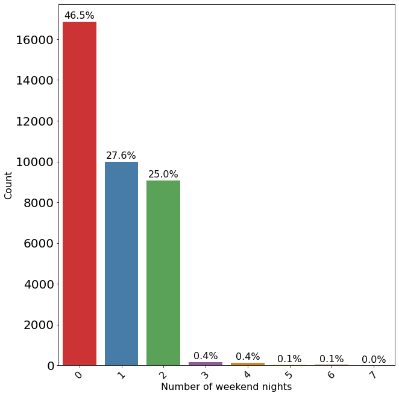

```python
labeled_barplot(data=data, feature='no_of_weekend_nights', xlabel='Number of weekend nights', ylabel='Count',perc=True)
```

##### Observations:

Approximately 46% of bookings are not made for weekend nights, which typically include a one- or two-day stay.

### Observation On Number Of Week Nights

```python
(data['no_of_week_nights']> 5).value_counts(normalize=True)*100
```

```
False   98.58580
True     1.41420
Name: no_of_week_nights, dtype: float64
```

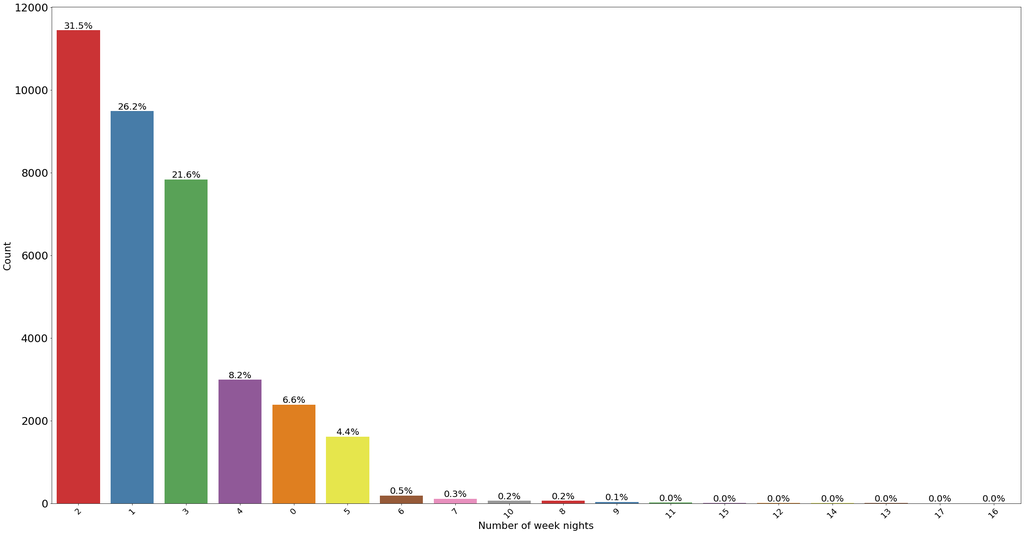

```python
labeled_barplot(data=data, feature='no_of_week_nights', xlabel='Number of week nights', ylabel='Count',perc=True)
```

#### Observations:

- The majority of bookings are made for 2 days of week nights, followed by 1 day of week night stays.
- Only approximately 1.5% of bookings are made for week night stays longer than 5 days.

### Observations On Type Of Meal Plan

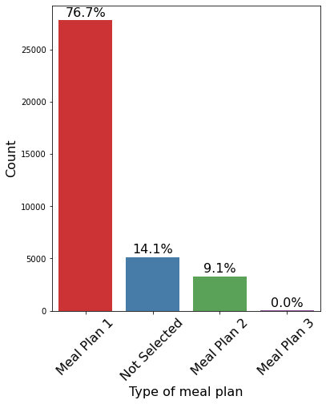

```python
labeled_barplot(data=data, feature='type_of_meal_plan', xlabel='Type of meal plan', ylabel='Count',perc=True)
```

##### Observations:

Approximately 76% of guests prefer Meal Plan 1, while 14% of guests do not select any meal plan.

### Observations On Required Car Parking Space

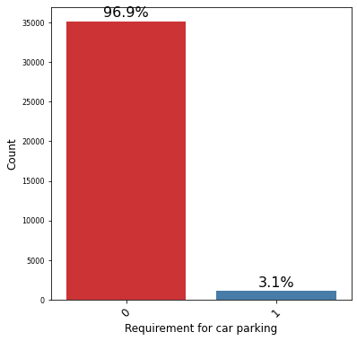

```python
labeled_barplot(data=data, feature='required_car_parking_space', xlabel='Requirement for car parking', ylabel='Count',perc=True)
```

###### Observations:

Approximately 97% of people don't require car parking.

### Observations On Room Type Reserved

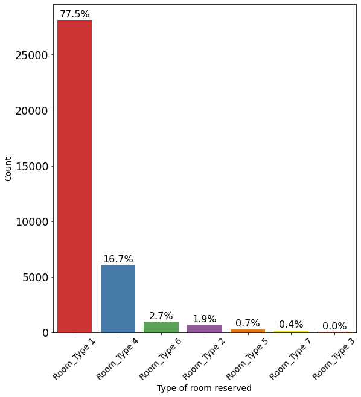

```python
labeled_barplot(data=data, feature='room_type_reserved', xlabel='Type of room reserved', ylabel='Count',perc=True)
```

### Observations:

Approximately 77% of guests prefer Room Type 1, followed by Room Type 4. Fewer people prefer other room types.

### Observations On Arrival Year

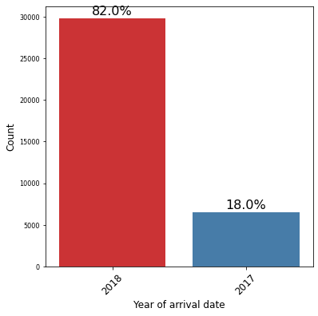

```python
labeled_barplot(data=data, feature='arrival_year', xlabel='Year of arrival date', ylabel='Count',perc=True)
```

##### Observations:

The majority of the observed data pertains to the year 2018.

### Observations On Arrival Month

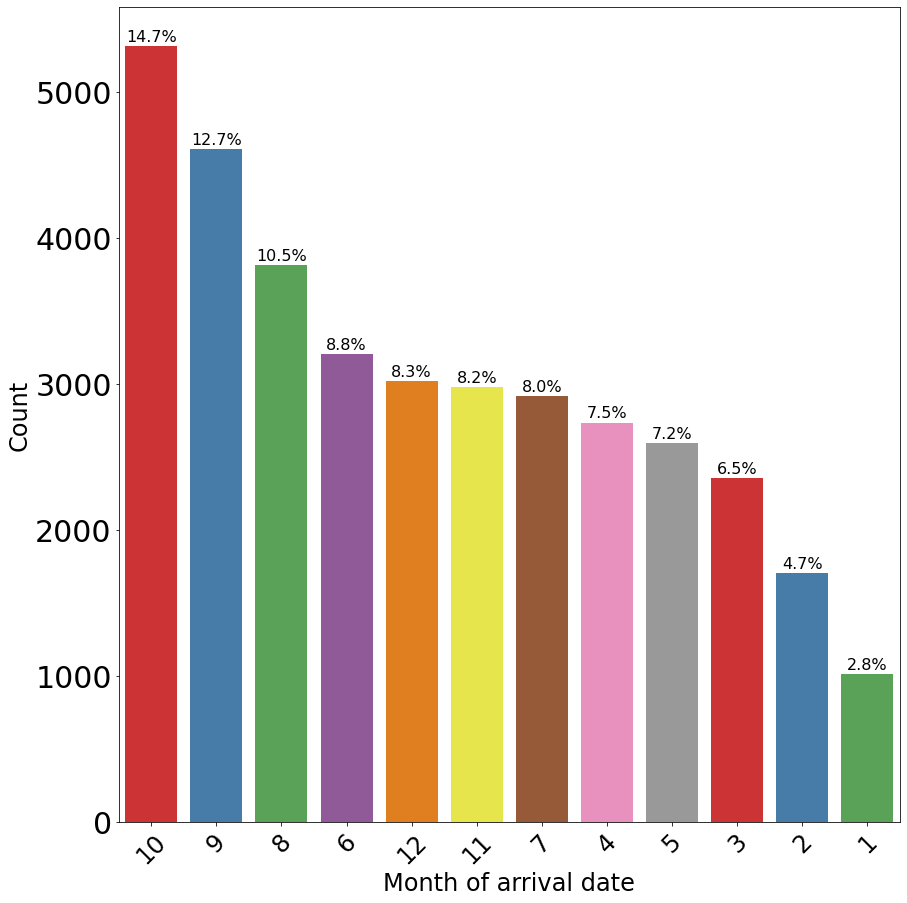

```python
labeled_barplot(data=data, feature='arrival_month', xlabel='Month of arrival date', ylabel='Count',perc=True)
```

##### Observations:

The months of October and September, followed by August, have the highest number of bookings, making them the busiest months for bookings. The months immediately before and after the peak booking season show moderate booking activity.

### Observations On Market Segment Type

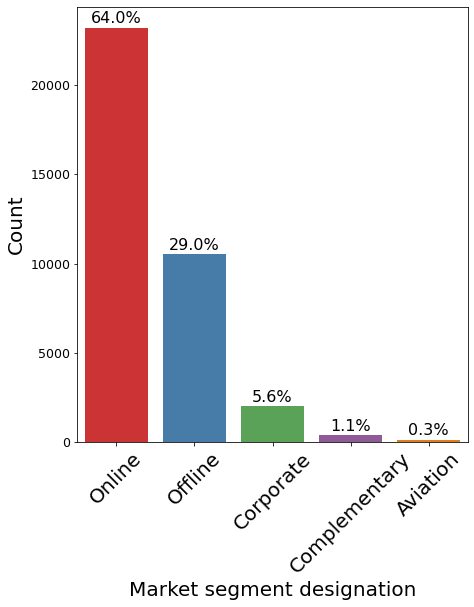

```python
labeled_barplot(data=data, feature='market_segment_type', xlabel='Market segment designation', ylabel='Count',perc=True)
```

##### Observations:

- Approximately 64% of the bookings are made online, while 29% are made offline.
- Corporate bookings account for approximately 5.6% of the total bookings.
- Around 1.1% of the bookings are made for complementary purposes.
- Bookings from the aviation sector constitute only 0.3% of the total bookings.

### Observation On Repeated Guest

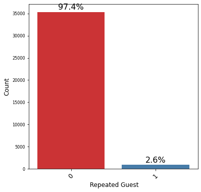

```python
labeled_barplot(data=data, feature='repeated_guest', xlabel=' Repeated Guest', ylabel='Count',perc=True)
```

##### Observations:

Majority of the guests, approximately 97.4%, are new guests, while only a small percentage of approximately 2.6% are repeat guests. This suggests that the hotel has a high rate of new guest bookings, with a relatively low percentage of repeat guests.

### Observation On Number Of Special Requests

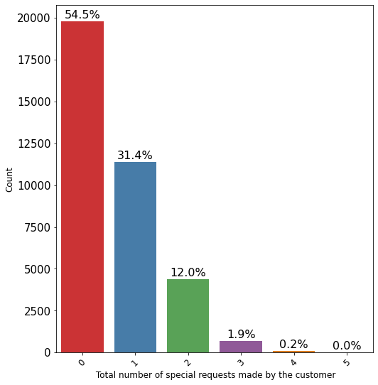

```python
labeled_barplot(data=data, feature='no_of_special_requests', xlabel=' Total number of special requests made by the customer', ylabel='Count',perc=True)
```

##### Observations:

- Approximately 54.5% of the total guests do not make any special requests, while about 43% of guests make 1-2 special requests.
- This suggests that a majority of guests do not have any special requirements or preferences during their stay, while a significant portion makes a moderate number of special requests.

### Observations On Booking Status

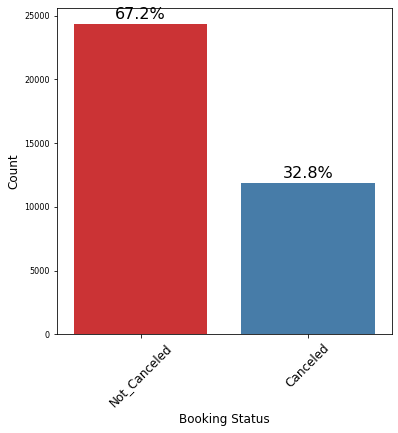

```python
labeled_barplot(data=data, feature='booking_status', xlabel='Booking Status', ylabel='Count',perc=True)
```

##### Observations:

- Around 67% of the bookings are not cancelled but 33% of them are cancelled.
- Majority of the bookings are confirmed and not cancelled, while a significant portion of bookings are cancelled by the guests.

##### Let's encode Canceled bookings to 1 and Not_Canceled as 0 for further target Variable analysis

```python
data["booking_status"] = data["booking_status"].apply(
    lambda x: 1 if x == "Canceled" else 0
)
```

## Bivariate Analysis

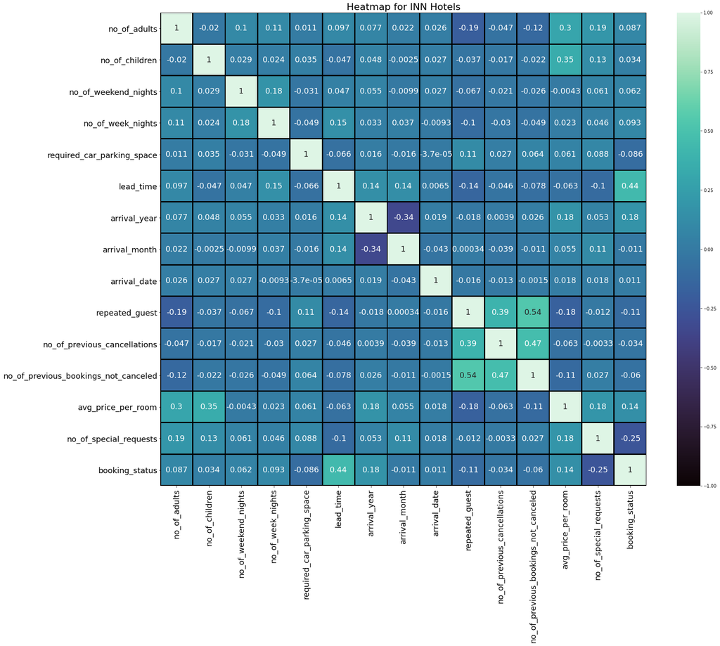

```python
cols_list = data.select_dtypes(include=np.number).columns.tolist()

plt.figure(figsize=(25,20))
hmap=sns.heatmap(data[cols_list].corr(),annot=True,cmap='mako',vmin=-1,vmax=1,linecolor='black',linewidths=2,annot_kws={'fontsize':18});
hmap.set_title('Heatmap for INN Hotels',fontsize=22)
hmap.set_xticklabels(hmap.get_xticklabels(), fontsize=18)
hmap.set_yticklabels(hmap.get_yticklabels(), fontsize=18)
plt.show()
```

### Books Status vs. Average Price

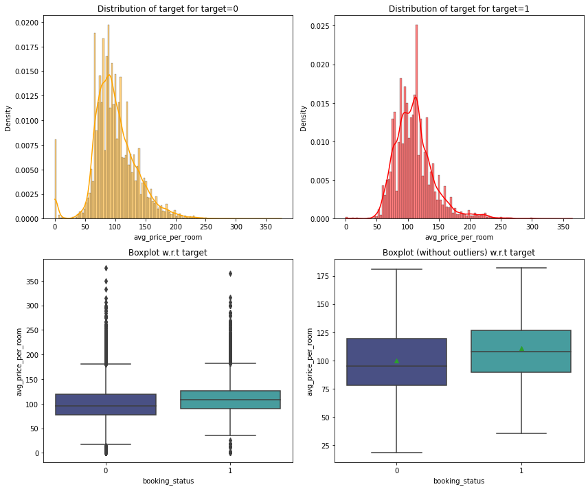

```python
distribution_plot_wrt_target(data, "avg_price_per_room", "booking_status",xlabel1="Average Price Per Room",xlabel2="Booking status")
```

##### Observations:

- The distribution of price for canceled bookings and not canceled bookings is quite similar.
- The prices for the canceled bookings are slightly higher than the bookings which were not canceled.

### Books Status vs. Lead Time

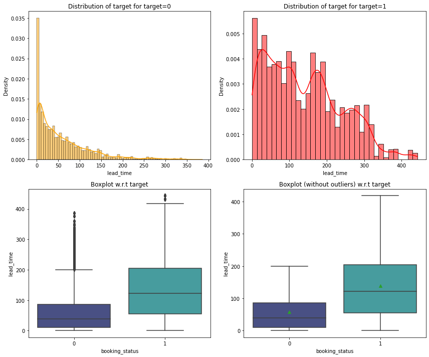

```python
distribution_plot_wrt_target(data, "lead_time", "booking_status",xlabel1="Lead Time",xlabel2="Booking Status")
```

##### Observations:

- Bookings that were canceled and bookings that were not canceled exhibit a significant disparity in their median lead time.
- Generally, bookings with longer lead times are more likely to be canceled

### Booking Status vs. Market Segment Type, Special Requests,Room Type Reserved and Meal Plan

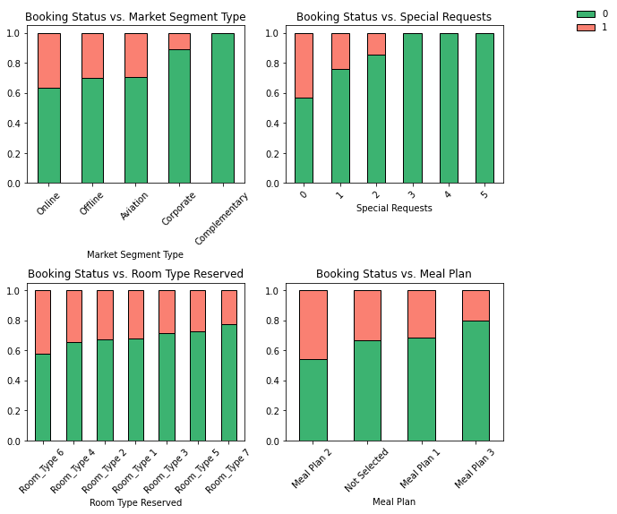

```python
# Create a grid of subplots with 2 rows and 2 columns
fig, axes = plt.subplots(2, 2, figsize=(8, 8))

# Call the function for each subplot and set title
ax1 = stacked_barplot(data, "market_segment_type", "booking_status", Xlabel='Market Segment Type', ax=axes[0, 0])
ax1.set_title('Booking Status vs. Market Segment Type')

ax2 = stacked_barplot(data, "no_of_special_requests", "booking_status", Xlabel='Special Requests', ax=axes[0, 1])
ax2.set_title('Booking Status vs. Special Requests')

ax3 = stacked_barplot(data, "room_type_reserved", "booking_status", Xlabel='Room Type Reserved', ax=axes[1, 0])
ax3.set_title('Booking Status vs. Room Type Reserved')

ax4 = stacked_barplot(data, "type_of_meal_plan", "booking_status", Xlabel='Meal Plan', ax=axes[1, 1])
ax4.set_title('Booking Status vs. Meal Plan')

# Add a common legend outside of the subplots
handles, labels = ax1.get_legend_handles_labels()
fig.legend(handles, labels, loc='upper right', bbox_to_anchor=(1.2,1.0), frameon=False)

# Adjust spacing between subplots
plt.tight_layout()

# Show the combined plot
plt.show()
```

```python
market_segment_booking_status_1 = data.groupby(['market_segment_type'])['booking_status'].value_counts(normalize=True)[data.groupby(['market_segment_type'])['booking_status'].value_counts(normalize=True).index.get_level_values('booking_status') == 1]*100
market_segment_booking_status_1
```

```
market_segment_type  booking_status
Aviation             1                29.60000
Corporate            1                10.90729
Offline              1                29.94871
Online               1                36.50814
Name: booking_status, dtype: float64
```

### Hotel rates are dynamic and change according to demand and customer demographics. Let's see how prices vary across different market segments

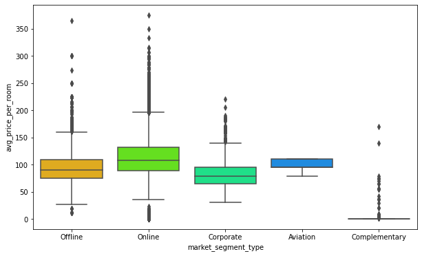

```python
plt.figure(figsize=(10, 6))
sns.boxplot(
    data=data, x="market_segment_type", y="avg_price_per_room", palette="gist_rainbow"
)
plt.show()
```

### Let's see if the special requests made by the customers impacts the prices of a room

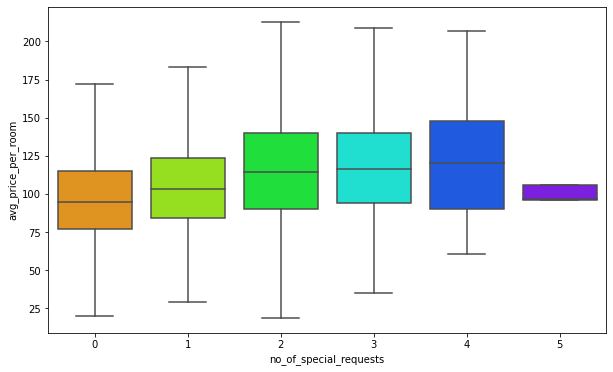

```python
# Writing the code to create boxplot for no of special requests and average price per room (excluding the outliers)
plt.figure(figsize=(10, 6))
sns.boxplot(
    data=data, x="no_of_special_requests", y="avg_price_per_room", palette="gist_rainbow",showfliers=False
)
plt.show()
```

### We saw earlier that there is a positive correlation between booking status and average price per room. Let's analyze it

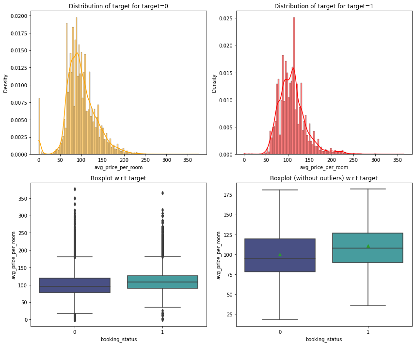

```python
distribution_plot_wrt_target(data, "avg_price_per_room", "booking_status",xlabel1='Average Price Per Room',xlabel2='Booking Status')
```

### There is a positive correlation between booking status and lead time also. Let's analyze it further

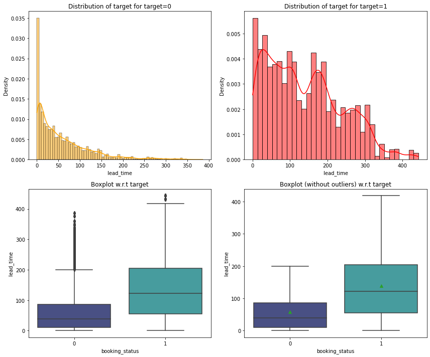

```python
# Writing the code to find distribution of lead time wrt booking status
distribution_plot_wrt_target(data, "lead_time", "booking_status",xlabel1='Lead Time',xlabel2='Booking Status')
```

## Data Preprocessing

- Missing value treatment (if needed)
- Feature engineering (if needed)
- Outlier detection and treatment (if needed)
- Preparing data for modeling
- Any other preprocessing steps (if needed)

### Generally people travel with their spouse and children for vacations or other activities. Let's create a new dataframe of the customers who traveled with their families and analyze the impact on booking status.

```python
family_data = data[(data["no_of_children"] >= 0) & (data["no_of_adults"] > 1)]
family_data.shape
```

```
(28441, 18)
```

```python
family_data["no_of_family_members"] = (
    family_data["no_of_adults"] + family_data["no_of_children"]
)
```

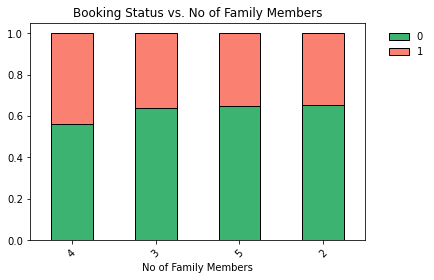

```python
# Writing the code to plot stacked barplot for no of family members and booking status
plt.figure(figsize=(6,4))
ax=stacked_barplot(family_data, "no_of_family_members", "booking_status",Xlabel='No of Family Members')
ax.set_title('Booking Status vs. No of Family Members')
ax.legend(loc='upper right',bbox_to_anchor=(1.2,1.0), frameon=False)
plt.show()
```

##### Observations:

Bookings that include 4 family members have a cancellation rate of approximately 40%.

### Let's do a similar analysis for the customer who stay for at least a day at the hotel.

```python
stay_data = data[(data["no_of_week_nights"] > 0) & (data["no_of_weekend_nights"] > 0)]
stay_data.shape
```

```
(17094, 18)
```

```python
stay_data["total_days"] = (
    stay_data["no_of_week_nights"] + stay_data["no_of_weekend_nights"]
)
```

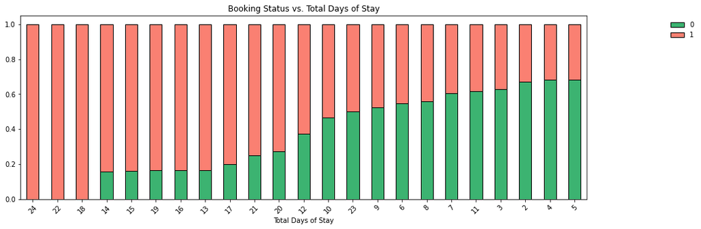

```python
# Writing the code to plot stacked barplot for total days and booking status
plt.figure(figsize=(15,5))
ax=stacked_barplot(stay_data, "total_days", "booking_status",Xlabel='Total Days of Stay')
ax.set_title('Booking Status vs. Total Days of Stay')
ax.legend(loc='upper right',bbox_to_anchor=(1.2,1.0), frameon=False)
plt.show()
```

##### Observations:

Cancellation rates tend to increase with the number of total days of stay.

##### Observations with Target Variable - Booking Status

- The prices for the canceled bookings are slightly higher than the bookings which were not canceled.
- Bookings with longer lead times are more likely to be canceled.
- Booking from Online marget segment has highest cancellation rate.
- Bookings with 3 or more special requests show 0 cancellations.
- Bookings that include 4 family members have a cancellation rate of approximately 40%.
- Cancellation rates tend to increase with the number of total days of stay.

## Answers to Leading Questions

### 1. What are the busiest months in the hotel?

### Let's find out what are the busiest months in the hotel.

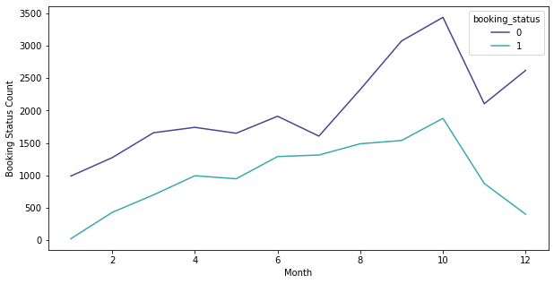

```python
monthly_data = data.groupby(["arrival_month", "booking_status"])["booking_status"].count().reset_index(name='Booking Status Count').rename(columns={'arrival_month': 'Month','booking_status':'Booking Status'})
# plotting the trend over different months
plt.figure(figsize=(10, 5))
# Converting booking_status column to categorical data type
monthly_data['booking_status'] = monthly_data['Booking Status'].astype('category')
sns.lineplot(data=monthly_data, x="Month", y="Booking Status Count",hue='booking_status',palette='mako')
plt.show()
```

##### Observations:

The month of October has the highest booking activity, followed by September and August.

### 2. Which market segment do most of the guests come from?

```python
data['market_segment_type'].value_counts()
```

```
Online           23214
Offline          10528
Corporate         2017
Complementary      391
Aviation           125
Name: market_segment_type, dtype: int64
```

##### Observations:

The majority of guests are from the Online market segment, followed by the Offline market segment.

### 3. Hotel rates are dynamic and change according to demand and customer demographics. What are the differences in room prices in different market segments?

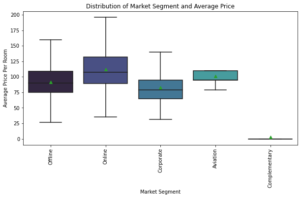

```python
plt.figure(figsize=(10, 5))
bplot=sns.boxplot(    data=data, x="market_segment_type", y="avg_price_per_room", palette="mako",showmeans=True,showfliers=False)
bplot.set_title('Distribution of Market Segment and Average Price')
plt.xlabel('Market Segment')
plt.ylabel('Average Price Per Room')
plt.xticks(rotation=90)
plt.show()
```

##### Observations:

- The box plot for the Online market segment is larger, indicating a higher variation in the average price per room compared to other market segments. This suggests that there may be a wider range of prices within the Online market segment, with some bookings having higher prices and others having lower prices.
- The Offline and Corporate market segments have similar box plot characteristics, showing similar variability in the average price per room. This could imply that these two segments have similar pricing patterns or strategies, with comparable ranges of prices.
- The Aviation market segment has a considerably smaller price range compared to Online, Offline, and Corporate. This suggests that the prices in the Aviation segment may be relatively consistent or less variable compared to other segments.
- The Complementary market segment shows an average price per room of 0 EUR, which may indicate free or complimentary bookings in this segment. This could be a special type of booking where the room charge is waived or included as part of a complementary package or service.

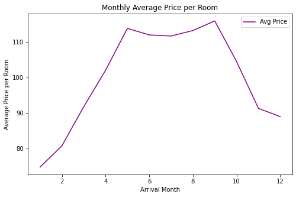

```python
# Set the figure size
plt.figure(figsize=(8, 5))
# Create the line plot
sns.lineplot(y=data["avg_price_per_room"], x=data["arrival_month"],ci=None,color='purple')

# Add labels and title
plt.xlabel("Arrival Month")
plt.ylabel("Average Price per Room")
plt.title("Monthly Average Price per Room")

 # Add a custom legend
plt.plot([],label="Avg Price",color='purple')
plt.legend()

# Show the plot
plt.show()
```

```python
data.groupby(['arrival_month'])['avg_price_per_room'].mean()
```

```
arrival_month
1     74.74976
2     80.73364
3     91.73084
4    101.99880
5    113.81068
6    111.96650
7    111.64932
8    113.20398
9    115.90692
10   104.46087
11    91.28543
12    88.95218
Name: avg_price_per_room, dtype: float64
```

```python
data[(data['arrival_month'] >= 5) & (data['arrival_month'] <= 9)]['avg_price_per_room'].mean()
```

```
113.52688422280602
```

### 4. What percentage of bookings are canceled?

### Let's check the percentage of bookings canceled in each month.

```python
#Returns the percentage of cancellation each month
data_cancellation_month=data.groupby(['booking_status'])['arrival_month'].get_group(1).value_counts(normalize=True)*100
# Create a dictionary to map month numbers to month names
month_dict = {1: 'January', 2: 'February', 3: 'March', 4: 'April', 5: 'May', 6: 'June', 7: 'July', 8: 'August', 9: 'September', 10: 'October', 11: 'November', 12: 'December'}
# Convert month numbers to month names using the apply function
data_cancellation_month.index = data_cancellation_month.index.map(month_dict)
# Display the result
print(data_cancellation_month)
```

```
October     15.81826
September   12.94068
August      12.51998
July        11.05595
June        10.86243
April        8.37190
May          7.97644
November     7.36222
March        5.88978
February     3.61801
December     3.38241
January      0.20194
Name: arrival_month, dtype: float64
```

[figure not shown]

```python
plt.figure(figsize=(8,5))
ax=stacked_barplot(data, "arrival_month", "booking_status",Xlabel='Arrival Month')
ax.set_title('Booking Status vs.Repeated Guests')
ax.legend(loc='upper right',bbox_to_anchor=(1.5,1.0), frameon=False)
plt.show()
```

##### Observations:

- There is a higher number of cancellations in October, followed by September and August, which coincides with the busiest months when more bookings are made and the average price per room is high compared to other months.
- This may suggest a potential relationship between higher booking activity, higher prices, and cancellations during the peak season months. Further analysis and investigation may be needed to understand the underlying reasons for this pattern.